# Физика ядерных взаимодействий. Термодинамика

# Введение

На основе расчётов решёточной КХД предполагается существование фазового перехода от адронного вещества к состоянию **почти свободного газа кварков и глюонов** — кварк-глюонной плазме. В связи с этим мы проанализируем свойства идеального газа кварков и глюонов в тепловом равновесии, а также фазовый переход между кварк-глюонной плазмой и адронной фазой. Такой подход является упрощением, основанным на т.н. асимптотической свободе в квантовой хромодинамике, определяющей поведение сильно взаимодействующих партонов при высоких температурах и плотностях. Хотя идеальный газ не может адекватно описывать динамическую эволюцию системы, поскольку термодинамика носит статический характер, данная модель представляет собой полезный иллюстративный пример.

Для наглядности фазовые переходы в ядерном веществе можно сопоставить с фазовыми переходами в воде. Фазовая диаграмма воды (рис. 1) демонстрирует области сосуществования фаз. При нормальном атмосферном давлении твёрдая, жидкая и газообразная фазы могут сосуществовать, что иллюстрируется такими повседневными примерами, как лёд в стакане воды (сосуществование твёрдой и жидкой фаз) и пар над кипящей водой (сосуществование жидкой и газовой фаз).

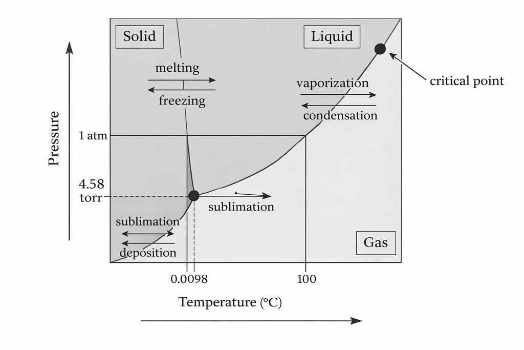

В точке фазового сосуществования температура системы остаётся постоянной, тогда как её объём может изменяться. Так, при кипении воды образующийся пар заполняет существенно больший объём, и процесс продолжается до полного испарения жидкости. Аналогично, температура смеси льда и воды не изменяется до полного плавления льда, после чего начинает возрастать. Подобные явления являются характерными признаками фазового перехода первого рода. В случае идеального газа, для которого выполняется уравнение состояния $PV=\nu RT$, сосуществование фаз при постоянной температуре происходит также при постоянном давлении, тогда как объём системы непрерывно увеличивается, что иллюстрируется на рис. 2.

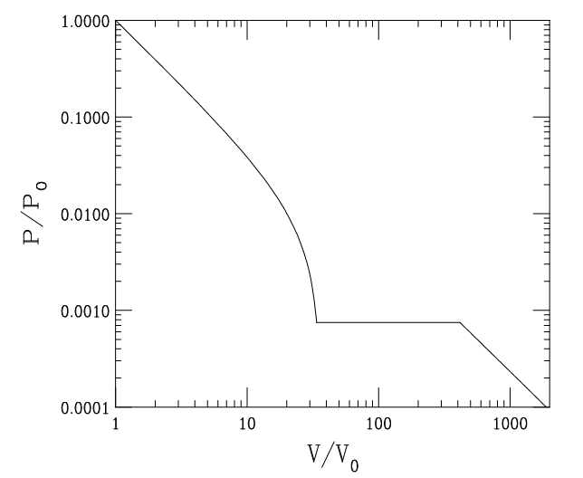

В фазовом переходе первого рода при сосуществовании фаз на границе сохраняются равенство давления, температуры и химического потенциала, однако наблюдается разрыв в плотности энергии до и после перехода. Этот разрыв соответствует **скрытой теплоте** и является определяющим признаком переходов первого рода. Поскольку выделение скрытой теплоты происходит не мгновенно, фазы могут длительно сосуществовать — как при кипении воды или плавлении льда. Подобные переходы трудно исследовать из-за сложной динамики процесса.

Не все фазовые переходы сопровождаются скачком плотности энергии. Если некоторая производная свободной энергии остаётся непрерывной на фазовой границе, а нулевой становится производная более высокого порядка, такой переход относится к переходам более высокого порядка.

*Наименьший порядок нулевой производной определяет порядок перехода; переход второго рода характеризуется обращением в нуль второй производной свободной энергии*.

**Переходы выше первого рода обычно называют непрерывными**; они не сопровождаются выделением скрытой теплоты.

## Фаза “кварк-материя”

В ядерной материи также существуют различные фазы. При нулевой температуре основное состояние — обычное ядерное вещество с плотностью энергии порядка $\varepsilon \approx 0{,}16 \, \text{ГэВ/фм}^3$ для покоящегося нуклона.

Схематическая фазовая диаграмма ядерного вещества для двух безмассовых лёгких кварков и тяжёлого странного кварка представлена на рис. 3. Фаза кварк-материи может быть достигнута либо при сильном сжатии ядерного вещества до высоких барионных плотностей при низких температурах, либо при нагревании вакуума до высоких температур.

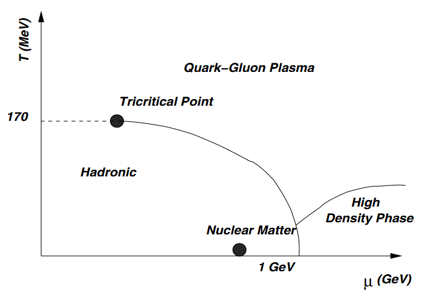

Фазы, возникающие при больших барионных плотностях и низких температурах, были изучены значительно позже, чем состояния при высоких температурах и малой плотности барионного числа. Предполагается, что такие фазы играют важную роль во внутренних областях нейтронных звёзд, в том числе в поддержании повышенной температуры их ядер на более длительных временных масштабах.

Высокотемпературная кварк-материя впервые возникла в природе в ходе ранних стадий эволюции Вселенной после Большого взрыва. Линия фазовых переходов первого рода завершается в области высоких температур в окрестности так называемой трикритической точки. Положение этой точки и характер перехода в экспериментально доступной области остаются предметом активных дискуссий: в зависимости от масс кварков $u, d$ и $s$ переход может быть второго рода или иметь характер сглаженного кроссовера.

## Нарушение и восстановление симметрии

Фазовые переходы, как правило, сопровождаются изменением симметрии системы. Для иллюстрации можно вновь обратиться к воде: жидкая фаза не обладает дальним порядком и принимает форму сосуда, тогда как твёрдая фаза — лёд — характеризуется определённой кристаллической симметрией; особенно наглядно это проявляется в структуре снежинок.

Аналогично, фазовые переходы в ядерной материи связаны с нарушением и восстановлением симметрий. В ранней Вселенной кварки были практически безмассовыми, и их количество совпадало с числом антикварков. В современном мире после перехода к обычному ядерному веществу массами лёгких кварков $u$ и $d$ уже присутствует различие, ещё более заметное при сравнении со странным кварком. Эти массы возникают вследствие спонтанного нарушения хиральной симметрии, которая при высоких температурах должна восстанавливаться (это будет подробно рассмотрено далее).

Современная Вселенная барионно-асимметрична: кварки связаны в обычное вещество, тогда как антибарионы практически отсутствуют и образуются лишь в лабораторных условиях. В тяжёлоионных столкновениях, напротив, ожидается примерно одинаковое число кварков и антикварков в центральной области быстроты.

Экспериментальные исследования в $AGS, SPS, RHIC$ и $LHC$ преимущественно охватывают область высоких температур и низких барионных плотностей, поэтому внимание в дальнейшем мы сосредоточим именно на этой части фазовой диаграммы. В то же время новая низкоэнергетическая установка $FAIR \;(GSI)$ будет более эффективна для изучения областей высоких плотностей.

# 1. Эргодическая гипотеза. Канонический ансамбль

Первый закон термодинамики устанавливает, что тепло является формой энергии. Второй закон в одной из эквивалентных формулировок утверждает: энтропия замкнутой системы остаётся постоянной или возрастает при снятии внутренних ограничений. Энтропия связана с числом доступных системе микросостояний.

Ансамбль — это **воображаемый набор очень большого числа копий одной и той же физической системы**, но каждая копия находится **в своём допустимом микросостоянии**. Все системы макроскопически идентичны (одинаковые энергия $E$, объем $V$, число частиц $N$)

Описание ансамбля задаётся **распределением вероятностей** по множеству микросостояний.

Мы не знаем, в каком именно микросостоянии сейчас находится наша реальная система. Поэтому мы **рассматриваем все возможные варианты сразу**. Ансамбль — это удобный статистический способ описания системы, не зная её точного состояния.

> Пример: У нас есть коробка с газом. Мы не можем измерить скорость каждого атома. Поэтому представляем 10²³ копий такой коробки, где в каждой — разные скорости частиц, но все копии подчиняются тем же внешним условиям.

**Замкнутая система** (фиксированные $E,V,N$) — порождает так называемый **микроканонический ансамбль**.

### Эргодическая гипотеза гласит:

> В длительной эволюции замкнутая система **посещает все доступные микросостояния** и **проводит одинаковое время** в каждом из них. Если бы мы могли наблюдать систему бесконечно долго, **временное** среднее совпало бы со **статистическим**:
> $$\overline{X(t)} = \langle X \rangle$$

То есть для определения параметров системы можно долго наблюдать за поведением одного её элемента, а можно за очень короткое время рассмотреть все её элементы (или достаточно много элементов). Если система обладает свойством эргодичности, то в обоих случаях получатся одинаковые результаты.

Каждое доступное квантовое состояние замкнутой системы равновероятно. Если системе доступно $\Omega$ состояний, то вероятность нахождения в состоянии $S$ равна:
$$P(S) = \frac{1}{\Omega}$$
при $P(S) = 0$ для недоступных состояний. Сумма вероятностей всех состояний равна единице.

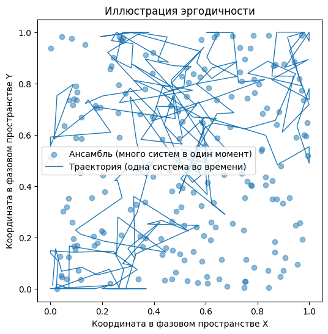

Если один из параметров ($E,V,N$) перестаёт быть фиксированным и увеличивается, возрастает число доступных состояний, а следовательно — и энтропия.

Если система не является замкнутой и зависит от некоторой величины $X$ (например, $E$, $V$ или $N$), то её среднее значение определяется как среднее по ансамблю:
$$\langle X \rangle = \sum_{S} X(S)\,P(S) =
\frac{1}{\Omega} \sum_{S} X(S)$$
**Канонический ансамбль** — статистический ансамбль, отвечающий физической системе, которая обменивается энергией с окружающей средой (термостатом), находясь с ней в тепловом равновесии, но не обменивается веществом, поскольку отделена от термостата непроницаемой для частиц перегородкой. Параметрами сокращенного описания такой системы являются число частиц $N$ и средняя энергия $\bar {E}$

# 2. Большой канонический ансамбль. Диффузионный контакт. Термодинамический и диффузионный контакт

**Большой канонический ансамбль** — статистический ансамбль, отвечающий физической системе, которая обменивается энергией и частицами с окружающей средой, но находится с ней в тепловом равновесии. ($T,V,\mu = Const$)

Справочная таблица по видам контакта и ансамблям, описывающим такую систему:

| Тип контакта | Что может меняться? | Какой ансамбль? |
| --- | --- | --- |
| Тепловой контакт | Энергия $(E)$ | Канонический $(T, V, N)$ |
| Диффузионный контакт | Число частиц $(N)$ | Большой канонический $(T, V, \mu)$ |
| Механический контакт | Объём $(V)$ | Изобарический $(T, P, N)$ |
| Все три контакта | $(E, V, N)$ | Изотермо-изобарный |

- **Тепловой контакт**: система может обмениваться теплом ⇒ фиксируется $T$ ($T_{A}=T_{B} ⇒$ нет теплового потока)
- **Диффузионный контакт**: система может обмениваться частицами ⇒ фиксируется $\mu$ ($μ_{A}=μ_{B}⇒$ нет потока частиц)

Итак, пусть у нас есть 2 системы, приведенные в *тепловой контакт*, энергия может передаваться между ними, образуя более крупную *замкнутую систему*: $S_1 +S_2$

У этой системы *постоянны* полная энергия и число частиц: $E = E_1 +E _2$ и $N = N_1 +N_2$

Эти величины могут перераспределяться между подсистемами разными способами. Однако **наиболее вероятным** распределением энергии будет то, при котором **число доступных микросостояний** всей системы максимально.

#### Почему?

Представим, что у нас есть изолированная система (например, газ в контейнере) с фиксированной энергией $E$. Энергия может распределяться между частицами разными способами.

- **Микросостояние** — это конкретный способ распределения энергии между частицами.
- **Макросостояние** — это совокупность микросостояний, характеризуемое, например, общими энергиями отдельных частей системы.
- Микросостояния могут быть $(2,0,0),(0,2,0),(0,0,2),(1,1,0),(1,0,1),(0,1,1)$.
- Если мы группируем по **макросостояниям** — например, по числу частиц с нулевой, единичной и двойной энергией — то одни макросостояния соответствуют большему числу микросостояний.

Вероятность макросостояния $P$ пропорциональна числу микросостояний $\Omega$, которые ему соответствуют:
$$P \propto \Omega$$
Почему так?
Потому что система в принципе «не различает» микросостояния — все они равновероятны (эргодическая гипотеза). Значит, чем больше микросостояний соответствует макросостоянию, тем больше шансов, что система будет находиться именно в нём. Для больших систем это распределение настолько доминирует, что почти всегда система его придерживается.

#### Вернемся к контакту двух систем

Если у системы $S_1$ энергия $E_1$, то у системы $S_2$ энергия $E - E_1$. Тогда число микросостояний полной системы:
$$\Omega(N, E) = \sum_{E_{1}}\Omega_1(N_1, E_1)\,\Omega_2(N_2, E - E_1).$$
Если произведение $\Omega_1\Omega_2$ *максимально* при $E_1 = E'_1$, то конфигурация
$$\Omega_1(N_1, E'_1)\,\Omega_2(N_2, E -
E'_1)$$
является наиболее вероятной. Для *больших систем* эта наиболее вероятная конфигурация определяет их макроскопические свойства. Если две большие системы в тепловом контакте хорошо описываются такой конфигурацией, они находятся в *тепловом равновесии*.

Для вычисления экстремума (наиболее вероятной конфигурации) необходимо, чтобы дифференциал $\Omega(N, E)$ обращался в ноль при малых изменениях энергии:
$$d \Omega = \Big(\frac{\partial \Omega_1}{\partial
E_1}\Big)_{N_{1}}\, \Omega_2 dE_1 + \Omega_1\Big(\frac{\partial
\Omega_2}{\partial E_2}\Big)_{N_{2}}\, dE_2 = 0, \quad \text{при } dE_1
+ dE_2 = 0.$$
Разделив на $\Omega_1 \Omega_2$ и учитывая, что энергия $E$ постоянна, условие теплового равновесия записывается как
$$\frac{1}{\Omega_1}
\Big(\frac{\partial \Omega_1}{\partial E_1}\Big)_{N_{1}} =
\frac{1}{\Omega_2} \Big(\frac{\partial \Omega_2}{\partial
E_2}\Big)_{N_{2}}$$
или, эквивалентно, через логарифм числа микросостояний:
$$\Big(\frac{\partial \ln
\Omega_1}{\partial E_1}\Big)_{N_{1}} = \Big(\frac{\partial \ln
\Omega_2}{\partial E_2}\Big)_{N_{2}}$$
**Энтропия** системы определяется как
$$S(N, E) = \ln
\Omega(N, E)$$
и *условие теплового равновесия окончательно принимает вид:*
$$\Big(\frac{\partial
S_1}{\partial E_1}\Big)_{N_{1}} = \Big(\frac{\partial S_2}{\partial
E_2}\Big)_{N_{2}}$$

Хотя здесь число частиц $N$ фиксировано, энтропия также может зависеть от объёма системы.

Следующий шаг — определение температуры. В тепловом равновесии температуры двух систем в контакте равны:
$$\Big(\frac{\partial S}{\partial E}\Big)_{N} =
\frac{1}{T},$$
где **$T$ — фундаментальная температура**, имеющая размерность энергии, так как энтропия безразмерна. Уравнение также справедливо при фиксированном объёме.

Энтропия увеличивается с числом доступных микросостояний. Общая энтропия всегда возрастает при приведении двух систем в тепловой контакт. Это известно как **закон возрастания энтропии** — энтропия либо остаётся постоянной, либо увеличивается при снятии внутреннего ограничения в системе.

Когда две системы приводятся в тепловой контакт, новым ограничением является сохранение суммы энергий $E_1 + E_2 = \text{const}$, а не энергий $E_1$ и $E_2$ по отдельности. Если системы разделить до достижения равновесия, система окажется в промежуточной конфигурации с промежуточной энтропией. Следовательно, *энтропия зависит от времени*, что будет изучено далее при рассмотрении гидродинамики.

Способы увеличения энтропии, релевантные при столкновениях тяжёлых ионов, включают добавление частиц, энергии и увеличение объёма.

Если рассмотреть систему с энергией $E'$, находящуюся в контакте с большим резервуаром энергии $E - E'$ (так что вся система имеет энергию $E$), то число доступных состояний для этой системы равно $\Omega(E - E')$. Система с равной вероятностью может иметь энергию $E''$ с числом состояний $\Omega(E - E'')$. Тогда отношение вероятностей равно отношению числа состояний:

$$\frac{P(E')}{P(E'')} =
\frac{\Omega(E - E')}{\Omega(E - E'')}$$
С учётом того, что $S = \ln \Omega$, имеем $\Omega = \exp(S)$ и
$$\frac{P(E')}{P(E'')} = \exp\big[ S(E
- E') - S(E - E'') \big]$$
Так как $E \gg E', E''$, можно разложить энтропию в ряд Тейлора около $S(E)$:
$$S(E - E') = S(E) - E' \frac{\partial S}{\partial E}\Big|_{V, N}
+ \dots \approx S(E) - \frac{E'}{T}$$
Подставляя это в уравнение видим, что члены $S(E)$ сокращаются, остаётся:
$$\exp\big[S(E - E') - S(E - E'')\big] \sim \exp\big[-(E'
- E'')/T\big]$$
Итого:
$$\frac{P(E')}{P(E'')} =
\frac{\exp(-E'/T)}{\exp(-E''/T)},$$

где $exp(-E'/T)$ — это **фактор Больцмана**.

Теперь определим давление через обратимый процесс.

В обратимом процессе система остаётся близкой к значению равновесной энтропии $S(V)$, так что при обратной смене условия система возвращается в исходное состояние. Энтропия такой системы остаётся фиксированной, и изменение называется **изоэнтропическим**.

Пример: бесконечно малое сжатие всех граней куба, изменяющее его объём с $V$ до $V - \Delta V$. Изменение энергии при этом записывается как
$$\Delta E = E(V - \Delta V) - E(V) = \frac{\partial E}{\partial V} \Delta
V$$
$$V=xyz$$
$$\Delta V = (\Delta x) y z + x (\Delta y) z + x y
(\Delta z)$$

Для куба:
$$\Delta V = 3 A \Delta L, \quad A = L^2$$

Изменение энергии при бесконечно малом сжатии $\Delta E$ определяется через давление $P$:
$$P = - \frac{\partial E}{\partial V}\Big|_S$$

где энтропия фиксирована (обратимый процесс). Если число частиц фиксировано, энтропия зависит только от $E$ и $V$:
$$dS(E, V) = \frac{\partial S}{\partial E}\Big|_V dE + \frac{\partial
S}{\partial V}\Big|_E dV \tag{*}$$

При фиксированной энтропии $dS = 0$. Вводим обозначения:
$$dE \equiv (\delta E)_S, \quad dV \equiv (\delta V)_S, \quad (\delta E)_S
/ (\delta V)_S \equiv \left(\frac{\partial E}{\partial V}\right)_S$$
Следовательно:
$$\frac{\partial S}{\partial V}\Big|_E = - \frac{\partial S}{\partial
E}\Big|_V \left(\frac{\partial E}{\partial V}\right)_S = - \frac{1}{T}
(-P) \quad \Rightarrow \quad \frac{\partial S}{\partial V}\Big|_E =
\frac{P}{T}$$
Итого уравнение ($*$) принимает следующий хорошо знакомый вид:
$$dE = T\, dS - P\, dV$$

#### Свободная энергия $F$

Изменение энергии в уравнении ($*$) включает вклад тепла $(T\,dS)$, добавленного к системе, и работу $(-P\,dV)$, совершаемую над системой. Работу, совершаемую над системой, можно связать с «полезной» энергией, извлекаемой из системы, поэтому **свободная энергия** определяется как
$$dF \equiv dE - T\,dS.$$
При фиксированных $V$ и $T$ $dE = T\,dS,$ что приводит к $dF = 0. \tag{4.21}$

Таким образом, свободная энергия минимальна для системы в тепловом контакте с термостатом при фиксированном объёме:
$$F = E - T S$$
Если число частиц не фиксировано, вводят **химический потенциал $\mu$**, определяющий перенос частиц между системами. Когда две системы могут обмениваться частицами, говорят, что они находятся в диффузионном контакте и достигают диффузионного равновесия, при котором между ними отсутствует чистый поток частиц. В диффузионном равновесии двух систем при фиксированном $N = N_1 + N_2$
$$dF = \frac{\partial F_1}{\partial N_1}\Big|_{T} dN_1 +
\frac{\partial F_2}{\partial N_2}\Big|_{T} dN_2 = 0.$$
Поскольку $dN=dN_1 + dN_2 = 0$, имеем условие равновесия:
$$\frac{\partial F_1}{\partial N_1}\Big|_{T} =
\frac{\partial F_2}{\partial N_2}\Big|_{T}.$$
Химический потенциал определяется как
$$\mu \equiv \frac{\partial F}{\partial N}\Big|_{T,V}.$$
Следовательно, в диффузионном равновесии $\mu_1 = \mu_2$

Энтропия является функцией $S(E,N,V)$. Тогда её дифференциал имеет вид
$$dS = \frac{\partial S}{\partial E}\Big|_{V,N} dE +
\frac{\partial S}{\partial V}\Big|_{E,N} dV +
\frac{\partial S}{\partial N}\Big|_{E,V} dN.$$
При фиксированных объёме и температуре: $(dV = 0, dT = 0)$. Тогда
$$(\delta S)_T =
\frac{\partial S}{\partial E}\Big|_{N} (\delta E)_T +
\frac{\partial S}{\partial N}\Big|_{E} (\delta N)_T.$$

Разделив на $(\delta N)_T$ и используя $\left(\frac{\partial S}{\partial E}\right)_N = \frac{1}{T}$, получаем
$$T \frac{\partial S}{\partial N}\Big|_{T}
=
\frac{\partial E}{\partial N}\Big|_{T}
+ T \frac{\partial S}{\partial N}\Big|_{T}.$$

Из определения химического потенциала следует
$$\mu = -T \frac{\partial S}{\partial N}\Big|_{E}$$

Подставляя определения $T, P, \mu$ в формула для $dS$, имеем
$$dS = \frac{1}{T}dE + \frac{P}{T}dV - \frac{\mu}{T}dN$$

В итоге получаем термодинамическое тождество:
$$dE = T\,dS - P\,dV + \mu\,dN \tag{**}$$

Введём удельные величины: $\varepsilon = E/V, s = S/V, n = N/V$, это плотность энергии, плотность энтропии и плотность числа частиц соответственно. Тогда
$$\varepsilon = sT - P + \mu n.$$
При $\mu = 0$: $\varepsilon + P = sT$

#### Обобщенная статсумма $Z$

Для обобщения факторов Больцмана учитываем обмен частицами с резервуаром:
$$\frac{P(N',E')}{P(N'' ,E'')}
=
\frac{\Omega(N-N',E-E')}{\Omega(N-N'',E-E'')}
=
\exp[S(N-N',E-E') - S(N-N'',E-E'')]$$
Раскладываем энтропию по Тейлору:
$$S(N-N',E-E')
\approx
S(N,E)
- \frac{\partial S}{\partial N}\Big|_{E} N'
- \frac{\partial S}{\partial E}\Big|_{N} E' + \dots
\approx
S(N,E)
+ \frac{N'\mu}{T}
- \frac{E'}{T}$$

В итоге
$$\frac{P(N',E')}{P(N'',E'')}
=
\frac{\exp[-(E' - N'\mu)/T]}{\exp[-(E'' -
N''\mu)/T]}$$

Экспонента в этой формуле — **фактор Гиббса**, соответствующий **большому каноническому ансамблю**.

Системы, находящиеся в тепловом и диффузионном контакте с тепловым резервуаром и, следовательно, способные обмениваться энергией и частицами с резервуаром, являются частью большого канонического ансамбля. Фактор Больцмана, введенный ранее относится к системам, находящимся в тепловом контакте. Такие системы являются частью канонического ансамбля. Для преобразования отношения вероятностей в абсолютные вероятности необходимо просуммировать факторы Гиббса по всем возможным состояниям с энергией $E$ и числом частиц $N$.

**Обобщенная статсумма** определяется как
$$Z_{\mathrm{gen}}
=
\sum_{N=0}^{\infty} \sum_{E(N)}
\exp\!\left[-\,\frac{E(N)-N\mu}{T}\right]$$
Абсолютные вероятности принимают вид
$$P(N',E')
=
\frac{1}{Z_{\mathrm{gen}}}
\exp\!\left[-\,\frac{E' - N'\mu}{T}\right]$$

# 3. Распределение Ферми-Дирака. Распределение Бозе-Эйнштейна

Фактор Гиббса является классическим пределом как распределения Ферми–Дирака, так и распределения Бозе–Эйнштейна. Для фермионов со спином $1/2$, которые подчиняются принципу Паули (на каждой орбитали может находиться либо $0$, либо $1$ частица данного сорта), распределение Ферми–Дирака имеет вид
$$f_{\text{FD}}(E,\mu)
=
\frac{1}{\exp[(E-\mu)/T]+1}. \tag{FD}$$

Здесь $\,\mu>0\,$ для частиц и $\,\mu<0\,$ для античастиц.
Для бозонов с целым спином, которые могут занимать одно квантовое состояние в неограниченном числе,
$$f_{\text{BE}}(E,\mu)
=
\frac{1}{\exp[(E-\mu)/T]-1}. \tag{BE}$$

#### Вывод распределений

Распределения Ферми-Дирака и Бозе-Эйнштейна можно вывести из их сумм Гиббса (обобщенной статсуммы). Функция распределения определяется как среднее число частиц, которые могут находиться в системе.

Для фермионов возможные значения числа частиц в состоянии: $N=0$ или $N=1$. Тогда обобщенная статсумма:
$$Z_{\mathrm{gen}}
=
\sum_{N=0}^{\infty} \sum_{E(N)}
\exp\!\left[-\,\frac{E(N)-N\mu}{T}\right] \quad\quad\quad\quad
Z_{\text{FD}} = 1 + \exp[-(E-\mu)/T].$$

Среднее число частиц (оно же абсолютная вероятность данного состояния):
$$\langle N \rangle_{\text{FD}}
=
\frac{\exp[-(E-\mu)/T]}{1+\exp[-(E-\mu)/T]}
=
\frac{1}{\exp[(E-\mu)/T]+1}
=
f_{\text{FD}}(E,\mu).$$

Для бозонов число частиц в состоянии $N=0,1,2,\dots$ и, если энергия каждой частицы равна $E$, то статсумма (по сути это геометрическая прогрессия):
$$Z_{\text{BE}}
=
\sum_{N=0}^{\infty}
\exp[-N(E-\mu)/T]
=
\frac{1}{1-\exp[-(E-\mu)/T]}.$$

Используя $\langle N\rangle = T \,\partial \ln Z/\partial\mu$ (будет доказано чуть ниже), и в бозонном случае $\ln Z=- \ln\!\left(1 - \exp[-(E-\mu)/T]\right),$ получаем
$$\langle N \rangle_{\text{BE}}
=
\frac{1}{\exp[(E-\mu)/T]-1}
=
f_{\text{BE}}(E,\mu).$$

*Можно обратить внимание, что при $\mu \to E$ знаменатель стремится к 0, т.е. в этом пределе (на очень низком уровне энергии) число частиц стремится к $\infty$ (конденсат Бозе-Эйнштейна)*

Замена $\mu \rightarrow -\mu$ даёт распределения для античастиц.

#### Единая форма обобщенной статсуммы

$$\boxed{Z_{\text{gen}}
=
\left(1 \mp \exp[-(E-\mu)/T]\right)^{\mp 1},}$$
где верхний знак ($-$) относится к бозонам, нижний ($+$) — к фермионам.

##### Вывод формулы $\langle N\rangle = T \,\partial \ln Z/\partial\mu$

Вероятность состояния даётся выражением
$$P(E,N)
=
\frac{1}{Z}
\exp\!\left[-\frac{E-\mu N}{T}\right] \;\;\;\;\;\;\;\;\;\;\;\;\; Z
=
\sum_{E,N}
\exp\!\left[-\,\frac{E-\mu N}{T}\right].$$
По определению, среднее число частиц в гранд-каноническом ансамбле равно
$$\langle N\rangle
=
\sum_{E,N}
N\,P(E,N)
=
\frac{1}{Z}
\sum_{E,N}
N\exp\!\left[-\frac{E-\mu N}{T}\right].$$

Рассмотрим производную логарифма статсуммы по химическому потенциалу:
$$\frac{\partial \ln Z}{\partial \mu}
=
\frac{1}{Z}\frac{\partial Z}{\partial \mu}.$$

Дифференцируя $Z$, получаем
$$\frac{\partial Z}{\partial \mu}
=
\frac{\partial}{\partial \mu}
\sum_{E,N}
\exp\!\left[-\frac{E-\mu N}{T}\right]
=
\sum_{E,N}
\exp\!\left[-\frac{E-\mu N}{T}\right]\cdot
\left(\frac{N}{T}\right).$$

Следовательно,
$$\frac{\partial Z}{\partial \mu}
=
\frac{1}{T}
\sum_{E,N}
N\exp\!\left[-\frac{E-\mu N}{T}\right].$$

Подставляя это обратно, имеем
$$\frac{\partial \ln Z}{\partial \mu}
=
\frac{1}{Z}
\cdot
\frac{1}{T}
\sum_{E,N}
N\exp\!\left[-\frac{E-\mu N}{T}\right]
=
\frac{1}{T}
\langle N\rangle.$$

Таким образом
$$\boxed{
\langle N\rangle
=
T\,\frac{\partial \ln Z}{\partial \mu}
}.$$

Итого обобщенная формула для среднего числа частиц для бозонов и фермионов:
$$T\,\frac{\partial \ln Z}{\partial \mu}
=
\frac{1}{\exp[(E-\mu)/T]\mp 1}
=
\langle N \rangle.$$

#### Классический предел (распределение Максвелла–Больцмана)

Если $\exp[(E-\mu)/T] \gg 1$, то
$$f_{\text{MB}}(E,\mu)
\approx
\exp[-(E-\mu)/T]
=
\lambda\,\exp(-E/T),$$
где $\lambda = \exp(\mu/T)$.

Это т.н. **распределение Максвелла-Больцмана**, а именно, классический предел ранее приведенной обобщенной формулы $\langle N \rangle=\frac{1}{\exp[(E-\mu)/T]\mp 1}$

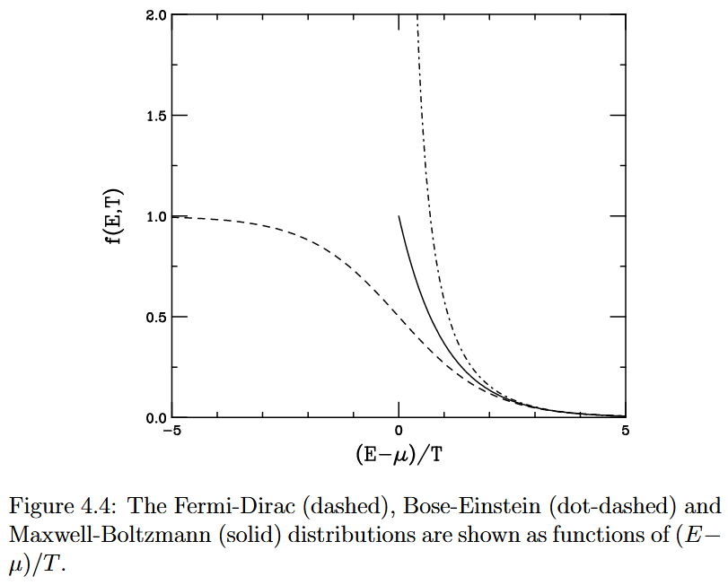

Рассмотрим классическую систему с большим числом частиц $N \sim 10^{23}$. Флуктуации числа частиц в большом каноническом ансамбле имеют порядок
$$\sigma_N \sim \sqrt{N}.$$
Тогда относительные флуктуации равны
$$\frac{\sigma_N}{N}
=
\frac{\sqrt{N}}{N}
=
\frac{1}{\sqrt{N}}
\ll 1.$$
Например, для $N \sim 10^{23}$ получаем $\frac{\sigma_N}{N} \sim 10^{-12}.$ Таким образом, $N \approx \langle N\rangle,$ то есть число частиц практически совпадает со своим средним значением. Число частиц ведёт себя как детерминированная величина, и флуктуациями можно пренебречь, система практически не замечает обмена частицами с резервуаром, все макроскопические величины имеют стабильные значения, применима классическая статистика

Поскольку флуктуации малы и частицы не взаимодействуют, каждая частица статистически независима от остальных. Это приводит к факторизации статистической суммы:

$$Z_N = \frac{(Z_1)^N}{N!},$$

где $Z_1$ — **одночастичная статсумма**, определяемая как сумма по микросостояниям *одной частицы*. Фактор $1/N!$ учитывает неразличимость частиц.

Таким образом, *термодинамика всего идеального газа сводится к статистике одной частицы и последующему умножению на $N$.*

Итак, в классическом случае полагая $N = \langle N \rangle$, имеем
$$N
=
\lambda\,Z_1,$$
где $Z_1$ — одночастичная статсумма.

##### Энергия свободной частицы массой $M$ в объеме $V$

Рассмотрим свободную частицу массы $M$, находящуюся в объёме
$$V = L^3,$$
ограниченном непроницаемыми стенками. Такая система описывается моделью частицы в трёхмерном потенциальном ящике с потенциальной энергией
$$V(\mathbf r)=
\begin{cases}
0, & 0<x,y,z<L, \\
\infty, & \text{вне ящика}.
\end{cases}$$

Внутри ящика частица свободна, поэтому её стационарное уравнение Шрёдингера имеет вид
$$-\frac{\hbar^2}{2M}\nabla^2\psi(x,y,z)=E\,\psi(x,y,z).$$

В силу аддитивности задачи по координатам волновую функцию можно искать в виде произведения
$$\psi(x,y,z)=X(x)\,Y(y)\,Z(z).$$
Каждая из функций удовлетворяет одномерному уравнению
$$-\frac{\hbar^2}{2M}\frac{d^2X}{dx^2}=E_x X,$$
и аналогичным уравнениям для координат $y$ и $z$.

Бесконечно высокие стенки ящика приводят к граничным условиям
$$X(0)=X(L)=0,$$
и аналогично для $Y$ и $Z$. Эти условия допускают решения в виде стоячих волн
$$X_{n_x}(x)=\sqrt{\frac{2}{L}}\sin\!\left(\frac{n_x\pi x}{L}\right),$$
где квантовое число $n_x=1,2,3,\dots$

Подстановка данного решения в уравнение Шрёдингера даёт собственные значения энергии в одном измерении:
$$E_x=\frac{\hbar^2\pi^2}{2ML^2}\,n_x^2.$$
Аналогично получаем $E_y$ и $E_z$

Полная энергия частицы равна сумме вкладов по всем координатам:
$$E_{n_x,n_y,n_z}=E_x+E_y+E_z.$$

Таким образом, спектр энергии свободной частицы в кубическом объёме имеет вид
$$E_{n_x,n_y,n_z}
=
\frac{\hbar^2 \pi^2}{2 M L^2}
\,(n_x^2+n_y^2+n_z^2).$$
Квантовые числа $n_x$, $n_y$ и $n_z$ определяют число полуволн стоячей волны в соответствующем направлении.

##### Обратно в статфизику

Переходя от суммы по квантовым числам к интегралу, получаем
$$Z_1
=
V\left(\frac{M T}{2\pi \hbar^2}\right)^{3/2}
=
n_Q\,V,$$
где $n_Q = \left(\frac{M T}{2\pi \hbar^2}\right)^{3/2}$ — квантовая концентрация.

Тогда
$$N = \lambda n_Q V,
\qquad
\lambda = \frac{n}{n_Q},
\qquad
n = \frac{N}{V},$$
и, следовательно,
$$\mu = T \ln\!\left(\frac{n}{n_Q}\right).$$
Если вспомнить определение химического потенциала как частной производной свободной энергии $\mu= (\frac{\partial F}{\partial N})_{{T,V}}$, можно выразить свободную энергию идеального газа:
$$F = \int_0^N \mu(N,T,V)\,dN.$$
Подставляя выражение для химического потенциала, получаем
$$F
=
T \int_0^N dN\,[\ln N - \ln(V n_Q)].$$
Используя тождество
$$\int dN\,\ln N = N\ln N - N,$$
и учитывая, что $\ln(V n_Q)$ не зависит от $N$, находим
$$F
=
T\,[N\ln N - N - N\ln(V n_Q)]
=
N T\!\left[\ln\!\left(\frac{N}{V n_Q}\right)-1\right].$$

Давление определяется как производная свободной энергии по объёму (проверил):
$$P = -\left(\frac{\partial F}{\partial V}\right)_{T,N}
= \frac{N T}{V}.$$
Таким образом, получаем уравнение состояния идеального газа:
$$P V = N T.$$
Энергия системы связана со свободной энергией соотношением
$$E = F + T S = F - T\left(\frac{\partial F}{\partial T}\right)_{V,N}.$$

Производная свободной энергии по температуре равна
$$\frac{\partial F}{\partial T}
=
N[\ln N - \ln(V n_Q) - 1]
-
N T\,\frac{1}{n_Q}\frac{\partial n_Q}{\partial T}.$$

Поскольку квантовая концентрация имеет размерность $n_Q \propto T^{3/2}$, имеем
$$\frac{\partial n_Q}{\partial T}
=
\frac{3}{2}\frac{n_Q}{T}.$$

Тогда последний член в выражении для $\partial F/\partial T$ равен $3N/2$. Подставляя это в выражение для энергии и умножая производную на $T$, первый член сокращается с $F$, и остаётся
$$E = \frac{3}{2}\,N T.$$
Итого, мы через статфизику чисто на конце пера получили основные формулы МКТ

# 4. Статистическая сумма в квантовой механике. Термодинамический потенциал Гиббса. Скорость звука

Полученная ранее обобщенная статсумма может быть использована для определения средних значений энергии и числа частиц, а также соответствующих плотностей. В наиболее общем виде статсумма формулируется с использованием операторов квантовой механики — гамильтониана $\hat H$ и оператора числа частиц $\hat N$.

Собственные состояния системы $|a\rangle$ определяются уравнениями
$$\hat H |a\rangle = E_a |a\rangle,
\qquad
\hat N |a\rangle = N_a |a\rangle.$$
Если $|a\rangle$ – собственное состояние системы, обобщенная статсумма записывается как сумма матричных элементов термодинамического потенциала:
$$Z
=
\sum_a
\langle a | \exp\!\left[-\frac{1}{T}(\hat H - \mu \hat N)\right] | a
\rangle \equiv
\mathrm{Tr}\,
\exp\!\left[-\frac{1}{T}(\hat H - \mu \hat N)\right]$$
где $\mathrm{Tr}$ обозначает след, то есть сумму диагональных элементов оператора в полном наборе собственных состояний.

Данное выражение является наиболее общим и применимо к системам с произвольным числом частиц — как фермионов, так и бозонов. Предполагая, что система находится в большом каноническом ансамбле, то есть в тепловом и диффузионном равновесии с резервуаром, энергия и число частиц флуктуируют около своих средних значений $\langle E\rangle$ и $\langle N\rangle$.

Плотность числа частиц определяется как
$$n
=
\frac{\langle N\rangle}{V}
=
\frac{1}{V}
\frac{
\mathrm{Tr}\left[
\hat N \exp\!\left(-\frac{\hat H - \mu \hat N}{T}\right)
\right]
}{
\mathrm{Tr}\left[
\exp\!\left(-\frac{\hat H - \mu \hat N}{T}\right)
\right]
}=
\frac{T}{V}\,
\frac{\partial \ln Z}{\partial \mu}.$$

Последнее следует из полученного ранее равенства $T\,\frac{\partial \ln Z}{\partial \mu}=\langle N \rangle.$

Аналогично, плотность энергии равна
$$\varepsilon
=
\frac{\langle E\rangle}{V}
=
\frac{1}{V}
\frac{
\mathrm{Tr}\left[
\hat H \exp\!\left(-\frac{\hat H - \mu \hat N}{T}\right)
\right]
}{
\mathrm{Tr}\left[
\exp\!\left(-\frac{\hat H - \mu \hat N}{T}\right)
\right]
}.$$

Связывая это выражение с производной по температуре, получаем
$$\varepsilon
=
\frac{T^2}{V}\,
\frac{\partial \ln Z}{\partial T}
+
\mu n.$$

##### Термодинамическое и статистическое определение свободной энергии $F$

При нулевом химическом потенциале свободная энергия определяется стандартным термодинамическим соотношением
$$F = E - TS,$$
Для системы с фиксированным объёмом $V$ энтропия как функция энергии и объёма удовлетворяет дифференциальному соотношению
$$dS(E,V)
=
\frac{1}{T}\,dE
+
\frac{P}{T}\,dV.$$
Умножая это выражение на $T$, получаем
$$T\,dS = dE + P\,dV.$$
Дифференциал свободной энергии имеет вид
$$dF = dE - T\,dS - S\,dT.$$
Подставляя выражение для $T\,dS$, находим
$$dF = -P\,dV - S\,dT.$$
Из этого следуют стандартные термодинамические определения:
$$S = -\left(\frac{\partial F}{\partial T}\right)_V,
\qquad
P = -\left(\frac{\partial F}{\partial V}\right)_T.$$
Используя выражение для энтропии, свободную энергию можно переписать в форме
$$F = E + T\left(\frac{\partial F}{\partial T}\right)_V.$$
Это соотношение эквивалентно дифференциальному уравнению второго порядка
$$E
=
-\,T^2
\frac{\partial}{\partial T}
\left(\frac{F}{T}\right)=-T^2\left(
\frac{1}{T}\frac{\partial F}{\partial T}
-
\frac{F}{T^2}\right)=
- T \frac{\partial F}{\partial T}
+
F$$

Сравнивая это выражение с формулой для плотности энергии при $\mu = 0$,
$$\varepsilon
=
\frac{T^2}{V}
\frac{\partial \ln Z}{\partial T},$$
получаем связь свободной энергии со статистической суммой:
$$\boxed{F = -T \ln Z}$$
*Статистическое определение полностью согласовано с термодинамическим*.

Из этого немедленно следуют выражения для давления и энтропии. Давление определяется как
$$P
=
-\left(\frac{\partial F}{\partial V}\right)_T
= \Big[\text{т.к. Z = Z(T,V)}\sim V, \frac{\partial \ln Z}{\partial
V}=\frac{1}{V}\Big] =\frac{T}{V}\ln Z,$$
а энтропия равна
$$S
=
-\left(\frac{\partial F}{\partial T}\right)_V
=
\frac{\partial}{\partial T}\left(T \ln Z\right).$$

#### Скорость звука в среде

Рассмотрим еще одно полезное соотношение при $\mu = 0$. Дифференциал энергии имеет вид
$$dE
=
T\,dS
+
S\,dT
-
P\,dV
-
V\,dP.$$
При фиксированном объёме $dV = 0$ и из условия
$$dE = T\,dS$$
следует
$$V\,dP = S\,dT.$$
Разделив обе части на $dE$, получаем
$$\frac{V\,dP}{dE}
=
\frac{S\,dT}{T\,dS}
=
\frac{d\ln T}{d\ln S}
\equiv c_s^2,$$
где **$c_s$ — скорость звука в среде**. Это величина из гидродинамики, эта связь нам еще понадобится Далее мы увидим, что для идеального газа безмассовых частиц
$$c_s^2 = \frac{1}{3} \;\;(\text{в единицах скорости света})$$

#### Термодинамический потенциал (Свободная энергия Гиббса)

При ненулевом химическом потенциале вводится потенциал Гиббса
$$G \equiv E - TS + PV.$$
Его полный дифференциал равен
$$dG
=
dE
-
T\,dS
-
S\,dT
+
P\,dV
+
V\,dP.$$

Используя термодинамическое тождество
$$dE = T\,dS - P\,dV + \mu\,dN,$$
получаем
$$dG
=
\mu\,dN
-
S\,dT
+
V\,dP.$$
Отсюда следуют определения
$$\mu
=
\left(\frac{\partial G}{\partial N}\right)_{T,P},
\qquad
S
=
-\left(\frac{\partial G}{\partial T}\right)_{N,P},
\qquad
V
=
\left(\frac{\partial G}{\partial P}\right)_{N,T}.$$
Если обмен частицами невозможен, $dN = 0$ и $dG = 0$. Это условие равновесия для систем, находящихся в тепловом и механическом контакте. Когда $dG = 0$, системы также находятся в диффузионном контакте. *Экстремум $G$ является минимумом, поскольку $G$ уменьшается с увеличением энтропии.*

При фиксированных $T$ и $P$ потенциал Гиббса $G$ также неизменен, поскольку энергия, энтропия и объем линейно возрастают с числом частиц, $G$ также прямо пропорциональна N
$$G(N,P,T) = N\,\mu(P,T).$$
Сравнивая это выражение с определением $G$, получаем термодинамическое тождество
$$E = TS + \mu N - PV.$$

Деля обе части на объём, приходим к плотностной форме:
$$\varepsilon = Ts + \mu n - P.$$
Прежде чем перейти к выводу конкретных результатов для плотности энергии, давления, энтропии и других термодинамических величин в системах, типичных для ядерных столкновений, мы обсудим фазовые переходы.

#### Экстенсивные и интенсивные величины

В термодинамике все макроскопические величины естественным образом делятся на **экстенсивные** и **интенсивные**

##### Экстенсивные величины

Величина $X$ называется **экстенсивной**, если при объединении двух независимых систем она складывается:
$$X_{\text{tot}} = X_1 + X_2.$$
Эквивалентно, при масштабировании системы в $\lambda$ раз выполняется
$$X(\lambda N, \lambda V, \lambda S) =
\lambda X(N,V,S).$$
К экстенсивным величинам относятся: $N, V, E, S, F, G, M$

Физически это означает, что экстенсивные величины пропорциональны размеру системы.

##### Интенсивные величины

Величина $Y$ называется **интенсивной**, если она не изменяется при масштабировании системы:
$$Y(\lambda N, \lambda V, \lambda S)
= Y(N,V,S).$$
Интенсивные величины не складываются при объединении систем, а выравниваются в состоянии равновесия.

К интенсивным величинам относятся: $T, P, \mu, n, \varepsilon.$